# Proyecto Econometria Kaggle

#Libreria

```r
rm(list = ls())

library(caret)
library(dplyr)
library(forcats)
library(ggplot2)
library(gridExtra)
library(Johnson)
library(lmtest) #Funcionalidad del Modelo
library(MASS)
library(PerformanceAnalytics)
```

#Cargar Data

```r
train <- read.csv("train.csv", sep=",")
train$longitude <- as.numeric(-1*train$longitude)
train <- train[-1]

test <- read.csv("test.csv", sep = ",")
test$longitude <- as.numeric(-1*test$longitude)
test <- test[-1]

#dim(train)
#dim(test)
```

# Imputacion Datos Fltantes - NA

```r
Na_train <- colnames(train)[!complete.cases(t(train))]
Na_test <- colnames(test)[!complete.cases(t(test))]

ABC <- is.na(train)
table(ABC)
```

```
ABC
 FALSE   TRUE
144326    144
```

## Separar variable para revisar NA

```r
var00 <- train %>%
  dplyr::select(Na_train)
```

[output not shown]

```r
var00
```

| total_bedrooms |
| --- |
| 152 |
| 767 |
| 463 |
| 661 |
| 312 |
| 449 |
| 291 |
| 320 |
| 301 |
| 386 |

[output cut: 990 more lines]

## Porcentaje de representacion NA

```r
porcentajeNA <- as.data.frame(apply(var00, MARGIN = 2, function(col) mean(is.na(col))))
colnames(porcentajeNA) <- c("porcentaje")
#porcentajeNA
```

NOTA: Se reviso la data en busca de NA y se encontro que: - La variable “total_bedrooms” es donde se encuentran esos NA - La data Train contiene 144 NA, los cuales representan el 0.009967467 de todos los datos. - La data Test contiene 63 NA, los que representan 0.01017278 - Se procede a realizar pruebas para completar estos valores con la media de los datos o la mediana.

## Completar NA con las media/mediana

```r
var00$total_bedrooms_mean <- ifelse(is.na(var00$total_bedrooms),
                               mean(var00$total_bedrooms, na.rm = TRUE),
                               var00$total_bedrooms)

var00$total_bedrooms_median <- ifelse(is.na(var00$total_bedrooms),
                               median(var00$total_bedrooms, na.rm = TRUE),
                               var00$total_bedrooms)
```

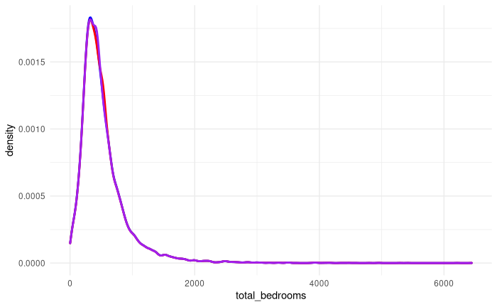

```r
var00 %>%
  ggplot(aes(x=total_bedrooms, y=..density..))+
  geom_density(color="blue", lwd=1) +
  geom_density(aes(x=total_bedrooms_mean, y=..density..), col="red", lwd=1)+
  geom_density(aes(x=total_bedrooms_median, y=..density..), col="purple", lwd=1)+
  theme_minimal()
```

Nota: - Se revisaron las estadisticas y se concluye que ambas metricas (media y mediana) conservan el comportamiento original de los datos. - Se procedera a completar los datos NA en la variable “total_bedrooms” con la media de los datos, para no perder la significancia estadistica.

# Nueva data, con los NA completados

```r
train$total_bedrooms <- ifelse(is.na(train$total_bedrooms),
                               mean(train$total_bedrooms, na.rm = TRUE),
                               train$total_bedrooms)

test$total_bedrooms <- ifelse(is.na(test$total_bedrooms),
                              mean(test$total_bedrooms, na.rm = TRUE),
                              test$total_bedrooms)
```

# Codificacion de variables categricas a numericas

```r
table(train$ocean_proximity)
```

```
 <1H OCEAN     INLAND     ISLAND   NEAR BAY NEAR OCEAN
      6368       4591          4       1625       1859
```

```r
table(test$ocean_proximity)
```

```
 <1H OCEAN     INLAND     ISLAND   NEAR BAY NEAR OCEAN
      2768       1960          1        665        799
```

# Nueva data con codificacion de variables categoricas

```r
subData<- train %>%
  dplyr::select(ocean_proximity)
OHE <- dummyVars("~.", data=subData)
OHE_dataframe <- data.frame(predict(OHE, newdata=subData))
train <- cbind(train, OHE_dataframe)
train <- train[-10]

subData<- test %>%
  dplyr::select(ocean_proximity)
OHE <- dummyVars("~.", data=subData)
OHE_dataframe <- data.frame(predict(OHE, newdata=subData))
test <- cbind(test, OHE_dataframe)
test <- test[-9]
```

# Analisis Estadistico de las Variables

```r
#summary(train)
#summary(test)
names(train)
```

```
 [1] "longitude"                 "latitude"                  "housing_median_age"        "total_rooms"               "total_bedrooms"            "population"                "households"
 [8] "median_income"             "median_house_value"        "ocean_proximity.1H.OCEAN"  "ocean_proximityINLAND"     "ocean_proximityISLAND"     "ocean_proximityNEAR.BAY"   "ocean_proximityNEAR.OCEAN"
```

# Feature Scaling (tamano de los valores)

## Normalizacion / Estandarizacion

```r
#norm_data <- scale(train)

train$longitude_std <- ((train$longitude - mean(train$longitude))/sd(train$longitude))
train$latitude_std <- ((train$latitude - mean(train$latitude))/sd(train$latitude))
train$housing_median_age_std <- ((train$housing_median_age - mean(train$housing_median_age))/sd(train$housing_median_age))
train$total_rooms_std <- ((train$total_rooms - mean(train$total_rooms))/sd(train$total_rooms))
train$total_bedrooms_std <- ((train$total_bedrooms - mean((train$total_bedrooms))/sd(train$total_bedrooms)))
train$population_std <- ((train$population -  mean(train$population))/sd(train$population))
train$households_std <- ((train$households - mean(train$households))/sd(train$households))
train$median_income_std <- ((train$median_income - mean(train$median_income))/sd(train$median_income))
```

## Normalizacion / Estandarizacion Variable Objetivo

```r
train$median_house_value_std <- ((train$median_house_value - mean(train$median_house_value))/sd(train$median_house_value))
```

## Normalizacion / Estandarizacion DataTest

```r
test$longitude_std <- ((test$longitude - mean(test$longitude))/sd(test$longitude))
test$latitude_std <- ((test$latitude - mean(test$latitude))/sd(test$latitude))
test$housing_median_age_std <- ((test$housing_median_age - mean(test$housing_median_age))/sd(test$housing_median_age))
test$total_rooms_std <- ((test$total_rooms - mean(test$total_rooms))/sd(test$total_rooms))
test$total_bedrooms_std <- ((test$total_bedrooms - mean((test$total_bedrooms))/sd(test$total_bedrooms)))
test$population_std <- ((test$population -  mean(test$population))/sd(test$population))
test$households_std <- ((test$households - mean(test$households))/sd(test$households))
test$median_income_std <- ((test$median_income - mean(test$median_income))/sd(test$median_income))
```

Acontinuacion se procedera a estudiar su representacion grafica, en busca de comportamiento.

# Comportamiento de los datos

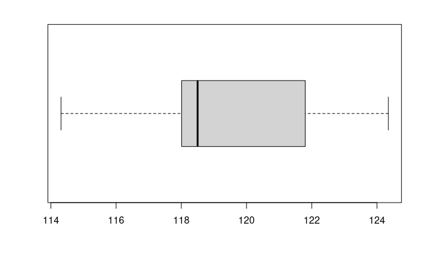

```r
boxplot(train$longitude, horizontal = TRUE)
```

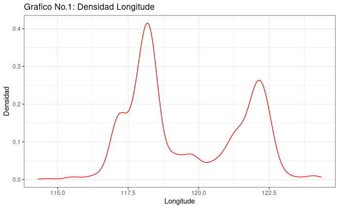

```r
train %>%
        ggplot(aes(x=longitude, y=..density..)) +
        geom_density(col="red") +
        labs(title = "Grafico No.1: Densidad Longitude",
         x = "Longitude",
         y = "Densidad") +
        theme_bw()
```

### Grafico No.2: latitude_std

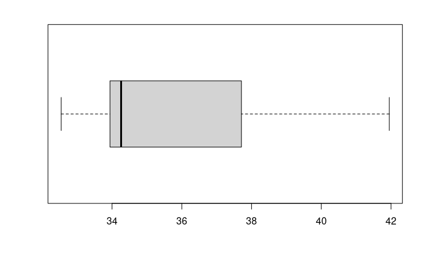

```r
boxplot(train$latitude, horizontal = TRUE)
```

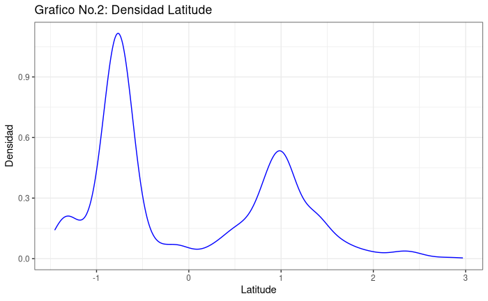

```r
train %>%
        ggplot(aes(x=latitude_std, y=..density..)) +
        geom_density(col="blue") +
        labs(title = "Grafico No.2: Densidad Latitude",
         x = "Latitude",
         y = "Densidad") +
        theme_bw()
```

### Grafico No.3: housing_median_age_std

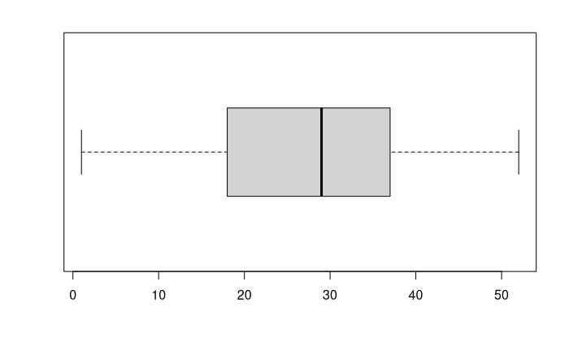

```r
boxplot(train$housing_median_age, horizontal = TRUE)
```

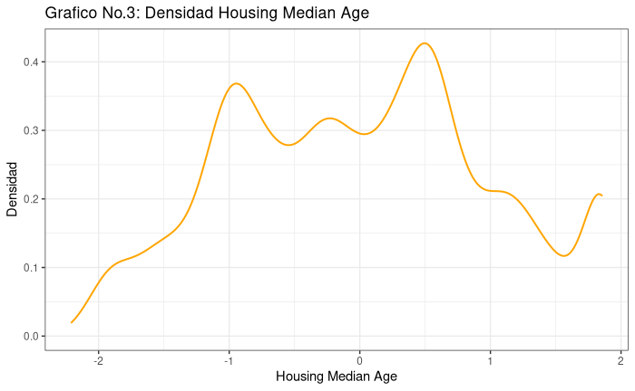

```r
train %>%
        ggplot(aes(x=housing_median_age_std, y=..density..)) +
        geom_density(col="orange", lwd=0.7) +
        labs(title = "Grafico No.3: Densidad Housing Median Age",
         x = "Housing Median Age",
         y = "Densidad") +
        theme_bw()
```

### Grafico No.4: total_rooms_std

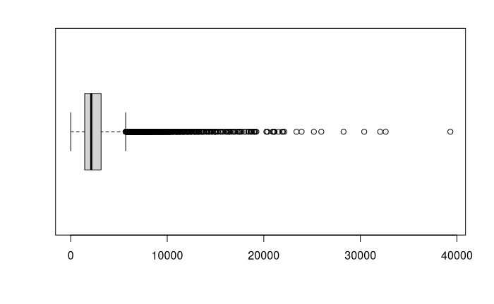

```r
boxplot(train$total_rooms, horizontal = TRUE)
```

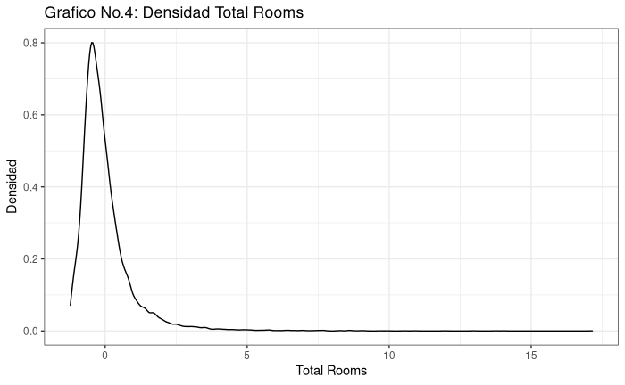

```r
train %>%
        ggplot(aes(x=total_rooms_std, y=..density..)) +
        geom_density(col="black") +
        labs(title = "Grafico No.4: Densidad Total Rooms",
         x = "Total Rooms",
         y = "Densidad") +
        theme_bw()
```

### Grafico No.5: total_bedrooms_std

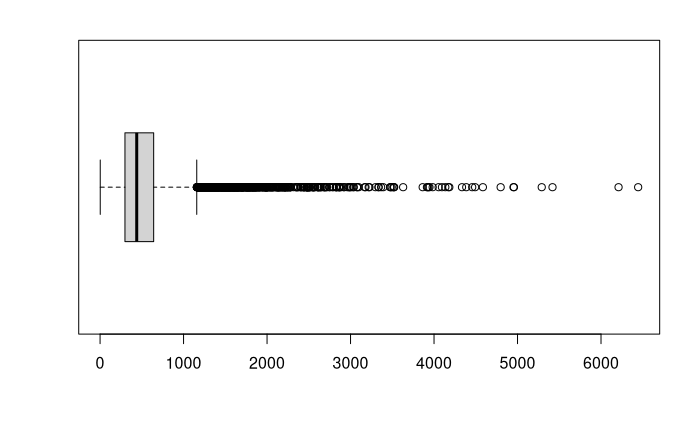

```r
boxplot(train$total_bedrooms, horizontal = TRUE)
```

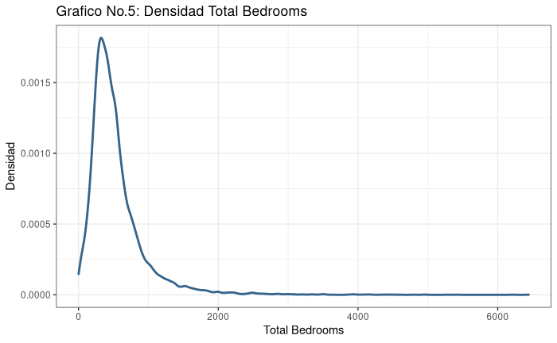

```r
train %>%
        ggplot(aes(x=total_bedrooms_std, y=..density..)) +
        geom_density(col="steelblue4", lwd=1) +
        labs(title = "Grafico No.5: Densidad Total Bedrooms",
         x = "Total Bedrooms",
         y = "Densidad") +
        theme_bw()
```

### Grafico No.6: population_std

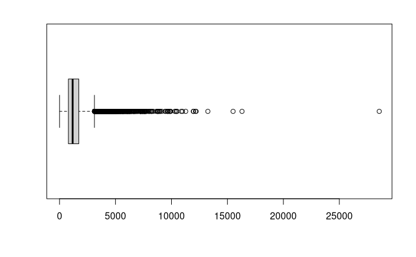

```r
boxplot(train$population, horizontal = TRUE)
```

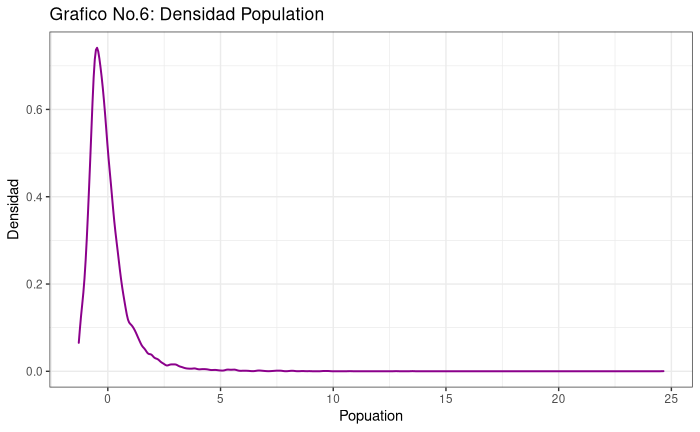

```r
train %>%
        ggplot(aes(x=population_std, y=..density..)) +
        geom_density(col="darkmagenta", lwd=0.7) +
        labs(title = "Grafico No.6: Densidad Population",
         x = "Popuation",
         y = "Densidad") +
        theme_bw()
```

### Grafico No.7: households_std

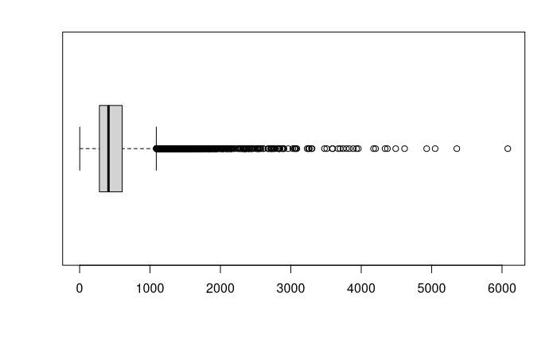

```r
boxplot(train$households, horizontal = TRUE)
```

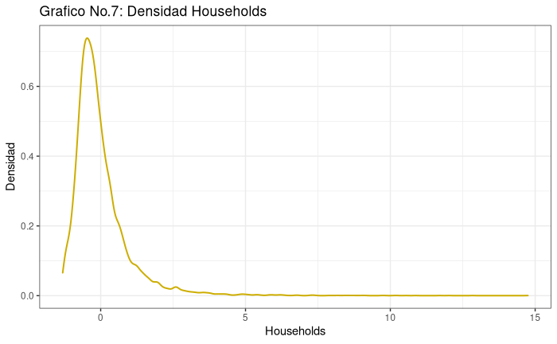

```r
train %>%
        ggplot(aes(x=households_std, y=..density..)) +
        geom_density(col="gold3", lwd=0.7) +
        labs(title = "Grafico No.7: Densidad Households",
         x = "Households",
         y = "Densidad") +
        theme_bw()
```

### Grafico No.8: median_income_std

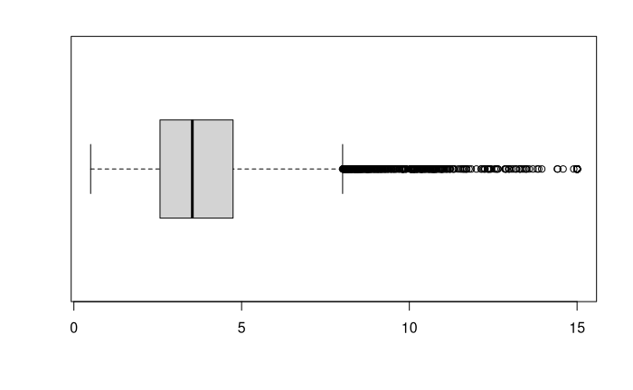

```r
boxplot(train$median_income, horizontal = TRUE)
```

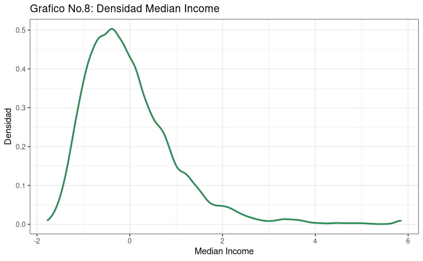

```r
train %>%
        ggplot(aes(x=median_income_std, y=..density..)) +
        geom_density(col="seagreen", lwd=1) +
        labs(title = "Grafico No.8: Densidad Median Income",
         x = "Median Income",
         y = "Densidad") +
        theme_bw()
```

### Grafico No.10: median_house_value_std

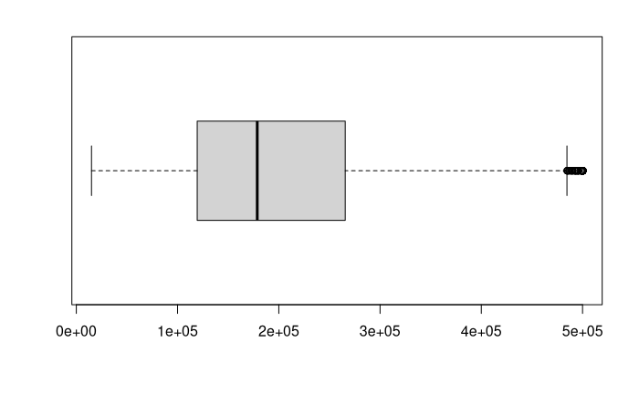

```r
boxplot(train$median_house_value, horizontal = TRUE)
```

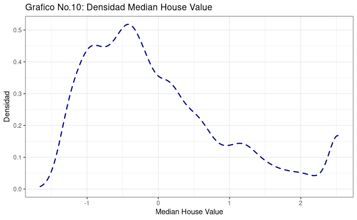

```r
train %>%
        ggplot(aes(x=median_house_value_std, y=..density..)) +
        geom_density(col="blue4", linetype = "dashed", lwd=0.8) +
        labs(title = "Grafico No.10: Densidad Median House Value",
         x = "Median House Value",
         y = "Densidad") +
        theme_bw()
```

# Transformacion de las Variables

Existen varios métodos estadísticos utiles para analizar datos donde la hipótesis de normalidad no es razonable o se ha demostrado empíricamente que no es.

1. Bootstrap
2. Tests no paramétricos
3. Tests de permutaciones
4. Modelos lineales generalizados
5. Transformación de datos
6. Estadística Robusta

## Test de normalidad

Los análisis de normalidad, también llamados contrastes de normalidad, tienen como objetivo analizar cuánto difiere la distribución de los datos observados respecto a lo esperado si procediesen de una distribución normal con la misma media y desviación típica.

Hipotesisi H0: La variable presenta una distribución normal H1: La variable presenta una distribución no normal

El p-value de estos test indica la probabilidad de obtener una distribución como la observada si los datos proceden realmente de una población con una distribución normal.

```r
library("tseries")
library("moments")
library("nortest")

#jarque.bera.test(x = train$longitude)
#ad.test(x=train$longitude) #Prueba Anderson-Darling
#lillie.test(x=train$longitude) #Prueba de Kolmogorov-smirnov
#pearson.test(x=train$longitude) #Prueba de Chi Cuadrada de Pearson
```

Importante: cuanto mayor sea el tamaño de la muestra, menos sensibles son los métodos paramétricos a la falta de normalidad. Por esta razón, es importante no basar las conclusiones únicamente en el p-value del test, sino también considerar la representación gráfica y el tamaño de la muestra.

## Transformacion

#### Transformación de datos Box-Cox

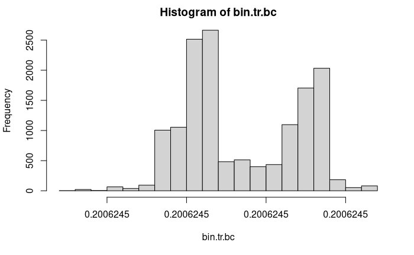

```r
library(MASS)
library(geoR)
Var01 <- as.numeric(train$longitude)

lambda = boxcoxfit(Var01)$lambda
bin.tr.bc =(((Var01)^lambda)-1)/(lambda)
hist(bin.tr.bc)
```

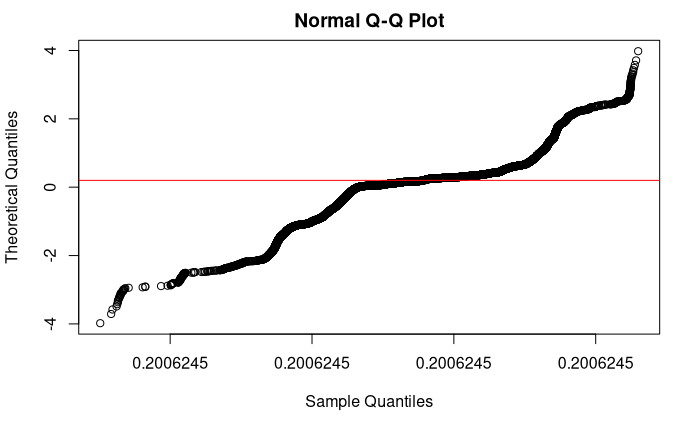

```r
qqnorm(bin.tr.bc, datax=T)
qqline(bin.tr.bc, col="red")
```

#### Johnson

```r
library("Johnson")

johnson_t <- RE.Johnson(Var01)
hist(johnson_t)
```

```
Error in hist.default(johnson_t) : 'x' must be numeric
```

#### Logaritmica

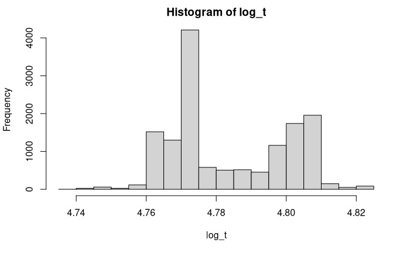

```r
log_t <- log(Var01)
hist(log_t)
```

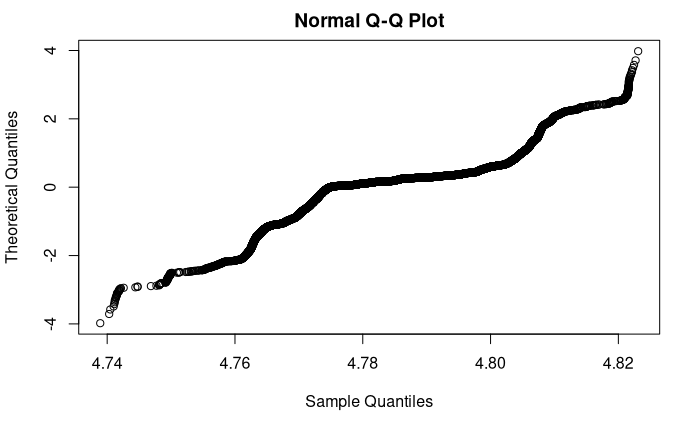

```r
qqnorm(log_t, datax=T)
qqline(log_t, col = "red")
```

#### Square root

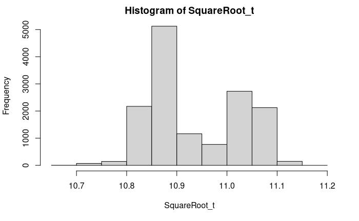

```r
SquareRoot_t <- sqrt(Var01)
hist(SquareRoot_t)
```

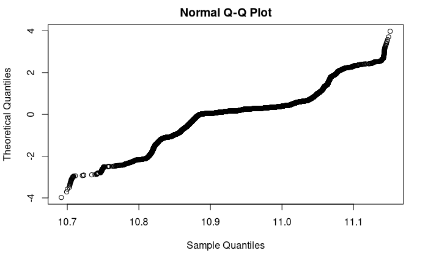

```r
qqnorm(SquareRoot_t, datax=T)
qqline(SquareRoot_t, col = "red")
```

#### Log squared

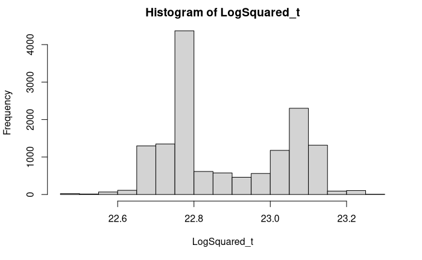

```r
LogSquared_t <- log(Var01)^2
hist(LogSquared_t)
```

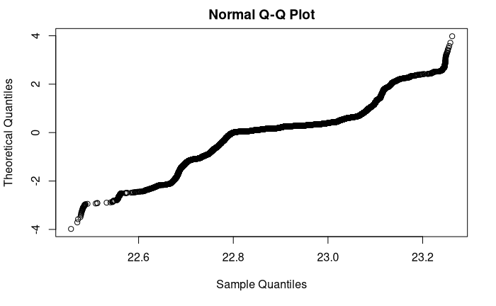

```r
qqnorm(LogSquared_t, datax=T)
qqline(LogSquared_t, col="red")
```

#### log exponent 1.5

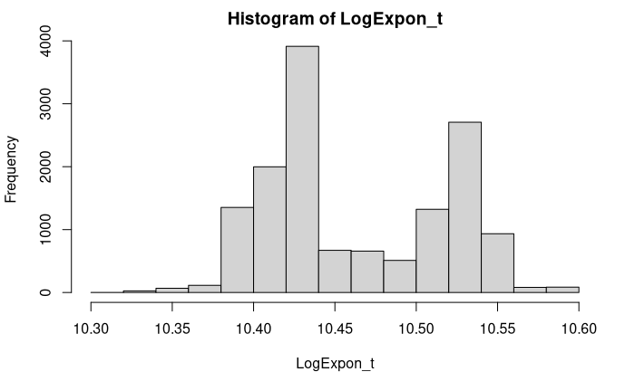

```r
LogExpon_t <- log(Var01)^1.5
hist(LogExpon_t)
```

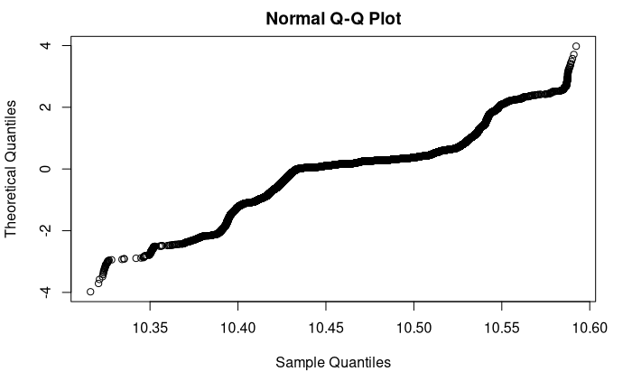

```r
qqnorm(LogExpon_t, datax=T)
qqline(LogExpon_t, col="red")
```

#### Cube root

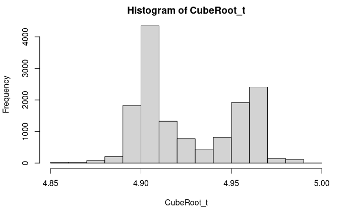

```r
CubeRoot_t <- (Var01)^(1/3)
hist(CubeRoot_t)
```

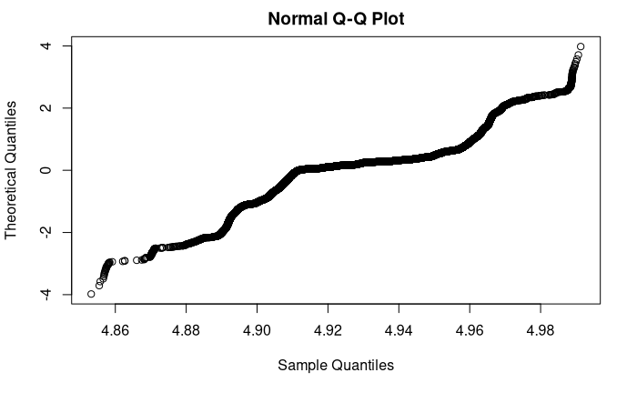

```r
qqnorm(CubeRoot_t, datax=T)
qqline(CubeRoot_t, col="red")
```

#### Desperate arcsin complex transformation

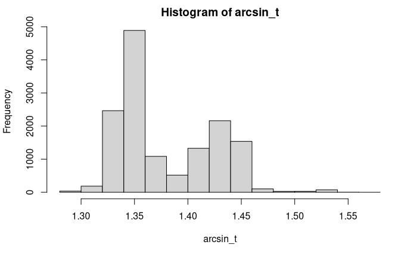

```r
arcsin_t <- asin((Var01/max(Var01))^(1/2))
hist(arcsin_t)
```

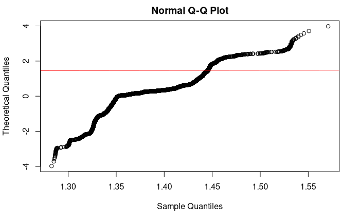

```r
qqnorm(arcsin_t, datax=T)
qqline(arcsin_t, col="red")
```

#### standard method or adhoc (abs(binomial - mean(binomial)))

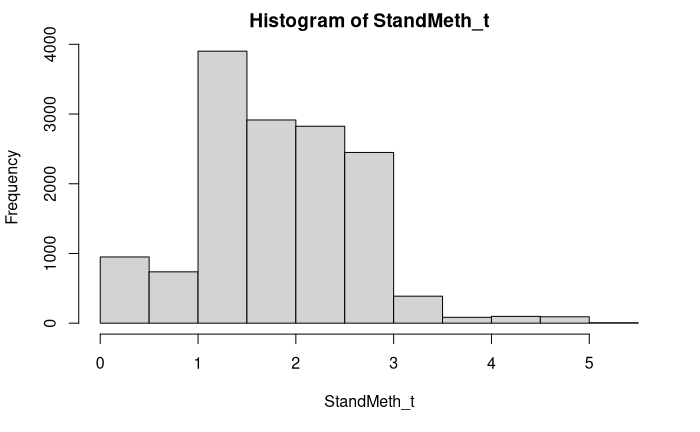

```r
StandMeth_t <- abs(Var01 - mean(Var01))
hist(StandMeth_t)
```

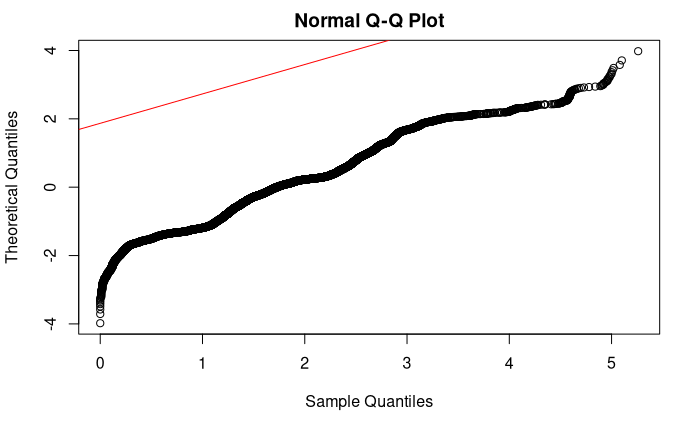

```r
qqnorm(StandMeth_t, datax=T)
qqline(StandMeth_t, col="red")
```

#### Transformacion Inversa

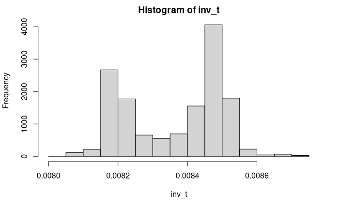

```r
inv_t <- 1/(Var01)
hist(inv_t)
```

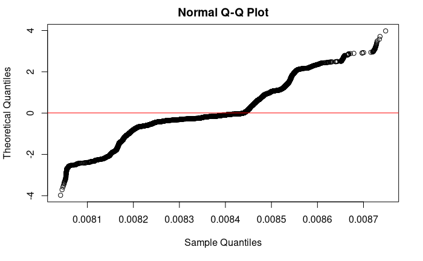

```r
qqnorm(inv_t, datax=T)
qqline(inv_t, col="red")
```

#### Métodos de remuestreo Bootstrap

La técnica de bootstrap consiste en obtener la distribución de un estadístico (al menos de forma aproximada) utilizando la información que se deriva de una sola muestra (y sus réplicas). Se genera una muestra con reemplazamiento.

Suponemos que la distribución bootstrap de un estadístico, obtenida a partir de una muestra aleatoria simple de tamaño n es aproximadamente normal y que el sesgo es pequeño.

El sesgo es la diferencia entre el estadístico de interés en la muestra original y el estadístico obtenido a partir de la distribución bootstrat).

Tiene los siguientes pasos: 1. decidir cuántas muestras de bootstrap realizar 2. cual es el tamaño de la muestra 3. para cada muestra de bootstrap: 4. extraer una muestra con reemplazo con el tamaño elegido 5. calcular la estadística de interés para esa muestra

```r
library(boot)
datos= data.frame(Var01)

media= function(datos, indices)
{
  d= datos[indices,]
  mean(d)
}
replicas = boot(data=datos, statistic =media, R=14447)
names(replicas)
```

```
 [1] "t0"        "t"         "R"         "data"      "seed"      "statistic" "sim"       "call"      "stype"     "strata"    "weights"
```

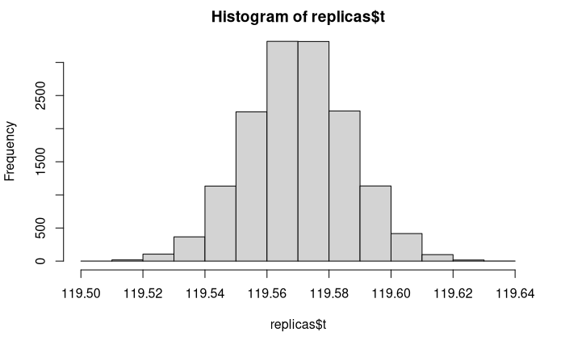

```r
hist(replicas$t)
```

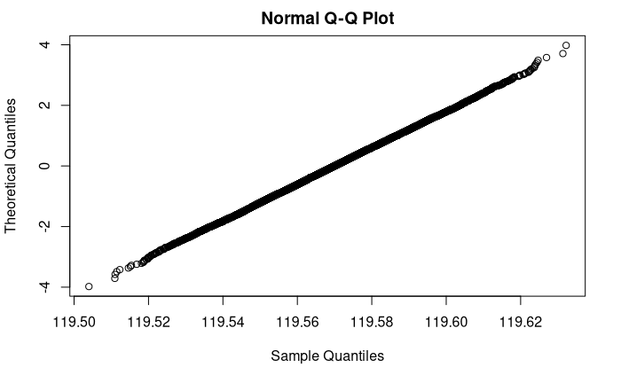

```r
qqnorm(replicas$t, datax=T)
qqline(replicas$t, col="red")
```

# Nueva data con variables transformadas

```r
train$longitude_t <- RE.Johnson(train$longitude_std)$transformed
train$latitude_t <- RE.Johnson(train$latitude_std)$transformed
train$housing_median_age_t <- asin((train$housing_median_age/max(train$housing_median_age))^(1/2))
train$total_rooms_t <- RE.Johnson(train$total_rooms)$transformed
train$total_bedrooms_t <- RE.Johnson(train$total_bedrooms)$transformed
train$population_t <- RE.Johnson(train$population)$transformed
train$households_t <- RE.Johnson(train$households)$transformed
train$median_income_t <- RE.Johnson(train$median_income)$transformed
train$median_house_value_t <- RE.Johnson(train$median_house_value)$transformed
names(train)
```

```
 [1] "longitude"                 "latitude"                  "housing_median_age"        "total_rooms"               "total_bedrooms"            "population"                "households"
 [8] "median_income"             "median_house_value"        "ocean_proximity.1H.OCEAN"  "ocean_proximityINLAND"     "ocean_proximityISLAND"     "ocean_proximityNEAR.BAY"   "ocean_proximityNEAR.OCEAN"
[15] "longitude_std"             "latitude_std"              "housing_median_age_std"    "total_rooms_std"           "total_bedrooms_std"        "population_std"            "households_std"
[22] "median_income_std"         "median_house_value_std"    "longitude_t"               "latitude_t"                "housing_median_age_t"      "total_rooms_t"             "total_bedrooms_t"
[29] "population_t"              "households_t"              "median_income_t"           "median_house_value_t"
```

```r
test$longitude_t <- RE.Johnson(test$longitude_std)$transformed
test$latitude_t <- RE.Johnson(test$latitude_std)$transformed
test$housing_median_age_t <- asin((test$housing_median_age/max(test$housing_median_age))^(1/2))
test$total_rooms_t <- RE.Johnson(test$total_rooms)$transformed
test$total_bedrooms_t <- RE.Johnson(test$total_bedrooms)$transformed
test$population_t <- RE.Johnson(test$population)$transformed
test$households_t <- RE.Johnson(test$households)$transformed
test$median_income_t <- RE.Johnson(test$median_income)$transformed
names(test)
```

```
 [1] "longitude"                 "latitude"                  "housing_median_age"        "total_rooms"               "total_bedrooms"            "population"                "households"
 [8] "median_income"             "ocean_proximity.1H.OCEAN"  "ocean_proximityINLAND"     "ocean_proximityISLAND"     "ocean_proximityNEAR.BAY"   "ocean_proximityNEAR.OCEAN" "longitude_std"
[15] "latitude_std"              "housing_median_age_std"    "total_rooms_std"           "total_bedrooms_std"        "population_std"            "households_std"            "median_income_std"
[22] "longitude_t"               "latitude_t"                "housing_median_age_t"      "total_rooms_t"             "total_bedrooms_t"          "population_t"              "households_t"
[29] "median_income_t"
```

# Manejo Outliers / Capping

### Datas para pruebas

```r
data_train <- dplyr::select(train, c(longitude_t, latitude_t, housing_median_age_t, total_rooms_t,
                              total_bedrooms_t, population_t, households_t, median_income_t,
                              ocean_proximity.1H.OCEAN, ocean_proximityINLAND, ocean_proximityISLAND,
                              ocean_proximityNEAR.BAY, ocean_proximityNEAR.OCEAN))

data_test <- dplyr::select(test, c(longitude_t, latitude_t, housing_median_age_t, total_rooms_t,
                            total_bedrooms_t, population_t, households_t, median_income_t,
                            ocean_proximity.1H.OCEAN, ocean_proximityINLAND, ocean_proximityISLAND,
                            ocean_proximityNEAR.BAY, ocean_proximityNEAR.OCEAN))
```

## Funcion detectar Outliers

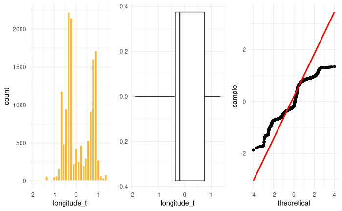

```r
detect_outliers <- function(df, colname){

  histPlot <- df %>%
    ggplot(aes_string(x=colname)) +
    geom_histogram(color='white', fill='orange', alpha=0.8)+
    theme_minimal()

  boxPlot <- df %>%
    ggplot(aes_string(x=colname))+
    geom_boxplot()+
    theme_minimal()

  qqPlot <- df %>%
    ggplot(aes_string(sample=colname))+
    stat_qq()+
    stat_qq_line(col="red", lwd=1)+
    theme_minimal()

  plotOut <- grid.arrange(histPlot, boxPlot, qqPlot, ncol=3)+
  theme(aspect.ratio = 5/50)

  return(plotOut)
}

detect_outliers(data_train, "longitude_t")
```

## Proceso Capping

```r
capping <- function(OutVar){
  IQR <- quantile(OutVar, 0.75)-quantile(OutVar,0.25)
  LS <- mean(OutVar) + 1.75*IQR
  LI <- mean(OutVar) - 1.75*IQR

  OutVar <- ifelse(OutVar >= LS, LS, OutVar)
  OutVar <- ifelse(OutVar <= LI, LI, OutVar)
  return(OutVar)
}
```

### Tratamiento Variables con Outliers en Data

#### train

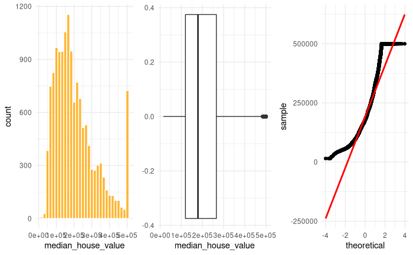

```r
train$longitude_outliers <- capping(train$longitude_t)
train$latitude_outliers <- capping(train$latitude_t)
train$housing_median_age_outliers <- capping(train$housing_median_age_t)
train$total_rooms_outliers <- capping(train$total_rooms_t)
train$total_bedrooms_outliers <- capping(train$total_bedrooms_t)
train$population_outliers <- capping(train$population_t)
train$households_outliers <- capping(train$households_t)
train$median_income_outliers <- capping(train$median_income_t)
train$median_house_value_outliers <- capping(train$median_house_value_t)

## VISUALUZACION
detect_outliers(train, "median_house_value")
```

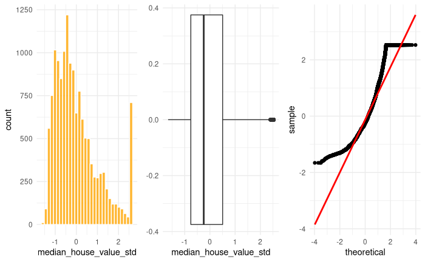

```r
detect_outliers(train, "median_house_value_std")
```

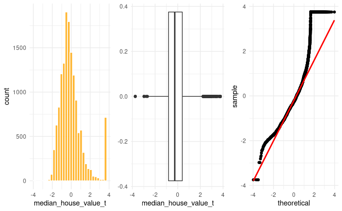

```r
detect_outliers(train, "median_house_value_t")
```

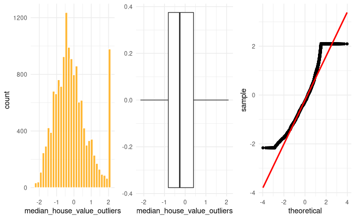

```r
detect_outliers(train, "median_house_value_outliers")
```

#### Tet

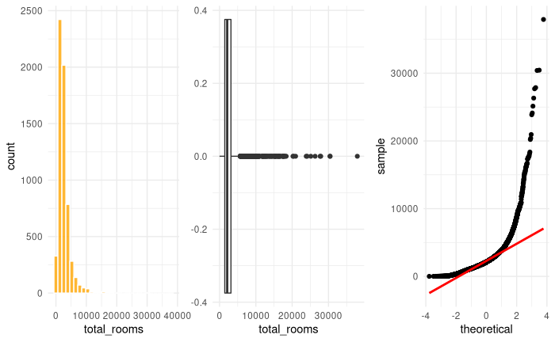

```r
test$longitude_outliers <- capping(test$longitude_t)
test$latitude_outliers <- capping(test$latitude_t)
test$housing_median_age_outliers <- capping(test$housing_median_age_t)
test$total_rooms_outliers <- capping(test$total_rooms_t)
test$total_bedrooms_outliers <- capping(test$total_bedrooms_t)
test$population_outliers <- capping(test$population_t)
test$households_outliers <- capping(test$households_t)
test$median_income_outliers <- capping(test$median_income_t)

## VISUALUZACION
detect_outliers(test, "total_rooms")
```

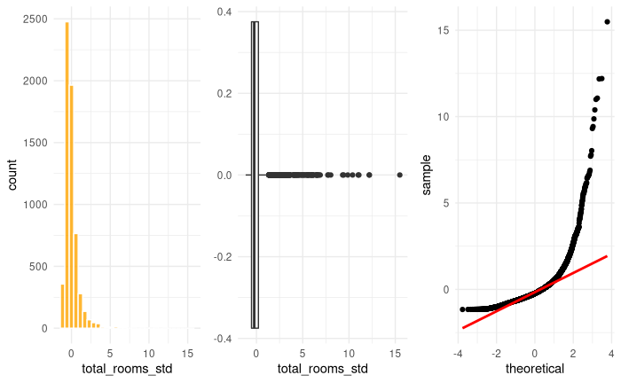

```r
detect_outliers(test, "total_rooms_std")
```

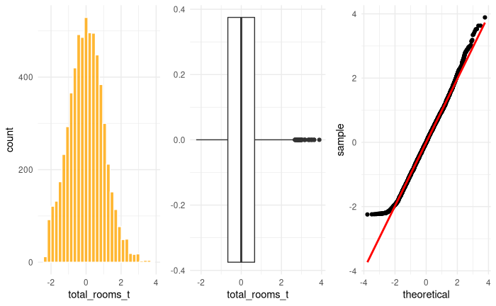

```r
detect_outliers(test, "total_rooms_t")
```

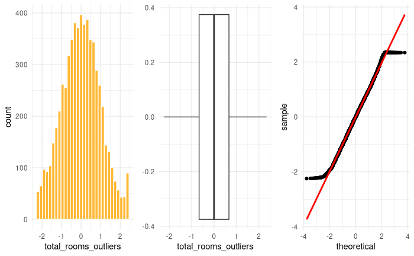

```r
detect_outliers(test, "total_rooms_outliers")
```

# Analisis de correlacion

```r
library(PerformanceAnalytics)
data_proy_train <- dplyr::select(train, c(longitude_outliers,latitude_outliers, housing_median_age_outliers, total_rooms_outliers,
                                   total_bedrooms_outliers, population_outliers, households_outliers, median_income_outliers,
                                   median_house_value_outliers))

X <- dplyr::select(train, c(longitude_outliers,latitude_outliers, housing_median_age_outliers, total_rooms_outliers,
                                   total_bedrooms_outliers, population_outliers, households_outliers, median_income_outliers))
y <- dplyr::select(train, median_house_value_outliers)
```

### Comportamiento de los datos

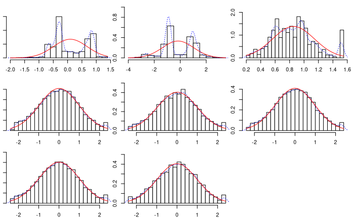

```r
library(psych)
multi.hist(x = X, dcol = c("blue", "red"), dlty = c("dotted", "solid"), main = "")
```

# Estimacion del Modelo

```r
#K-Folds.
set.seed(1234)
customControl<-trainControl(method = "repeatedcv", number=10, repeats=5, verboseIter = F)

set.seed(1234)
mod01 <-train(median_house_value_outliers ~., data_proy_train, method="lm", trControl=customControl)
mod01
```

```
Linear Regression

14447 samples
    8 predictor

No pre-processing
Resampling: Cross-Validated (10 fold, repeated 5 times)
Summary of sample sizes: 13002, 13003, 13001, 13002, 13002, 13002, ...
Resampling results:

  RMSE      Rsquared   MAE
  0.604695  0.6221948  0.4568557

Tuning parameter 'intercept' was held constant at a value of TRUE
```

```r
summary(mod01)
```

```
Call:
lm(formula = .outcome ~ ., data = dat)

Residuals:
    Min      1Q  Median      3Q     Max
-2.9398 -0.3830 -0.0684  0.3247  4.8644

Coefficients:
                             Estimate Std. Error t value Pr(>|t|)
(Intercept)                 -0.746678   0.016875  -44.25   <2e-16 ***
longitude_outliers           0.825632   0.022973   35.94   <2e-16 ***
latitude_outliers           -0.450797   0.011410  -39.51   <2e-16 ***
housing_median_age_outliers  0.545507   0.019144   28.49   <2e-16 ***
total_rooms_outliers        -0.392808   0.020686  -18.99   <2e-16 ***
total_bedrooms_outliers      0.520498   0.025881   20.11   <2e-16 ***
population_outliers         -0.476414   0.013388  -35.58   <2e-16 ***
households_outliers          0.361885   0.027409   13.20   <2e-16 ***
median_income_outliers       0.748441   0.007765   96.39   <2e-16 ***
---
Signif. codes:  0 ‘***’ 0.001 ‘**’ 0.01 ‘*’ 0.05 ‘.’ 0.1 ‘ ’ 1

Residual standard error: 0.6046 on 14438 degrees of freedom
Multiple R-squared:  0.6225,    Adjusted R-squared:  0.6223
F-statistic:  2976 on 8 and 14438 DF,  p-value: < 2.2e-16
```

## Ridge Regression:

library(MASS) library(PerformanceAnalytics)

set.seed(1234) ridge<-train(median_house_value_outliers ~., data_proy_train, method=“glmnet”, tuneGrid = expand.grid(alpha = 0, lambda=seq(0.0001, 1, length=5)), trControl=customControl)

## Modelo con todas las Variables

```r
mod00 <- lm(median_house_value_outliers ~., data = data_proy_train)
summary(mod00)
```

```
Call:
lm(formula = median_house_value_outliers ~ ., data = data_proy_train)

Residuals:
    Min      1Q  Median      3Q     Max
-2.9398 -0.3830 -0.0684  0.3247  4.8644

Coefficients:
                             Estimate Std. Error t value Pr(>|t|)
(Intercept)                 -0.746678   0.016875  -44.25   <2e-16 ***
longitude_outliers           0.825632   0.022973   35.94   <2e-16 ***
latitude_outliers           -0.450797   0.011410  -39.51   <2e-16 ***
housing_median_age_outliers  0.545507   0.019144   28.49   <2e-16 ***
total_rooms_outliers        -0.392808   0.020686  -18.99   <2e-16 ***
total_bedrooms_outliers      0.520498   0.025881   20.11   <2e-16 ***
population_outliers         -0.476414   0.013388  -35.58   <2e-16 ***
households_outliers          0.361885   0.027409   13.20   <2e-16 ***
median_income_outliers       0.748441   0.007765   96.39   <2e-16 ***
---
Signif. codes:  0 ‘***’ 0.001 ‘**’ 0.01 ‘*’ 0.05 ‘.’ 0.1 ‘ ’ 1

Residual standard error: 0.6046 on 14438 degrees of freedom
Multiple R-squared:  0.6225,    Adjusted R-squared:  0.6223
F-statistic:  2976 on 8 and 14438 DF,  p-value: < 2.2e-16
```

## Residuos

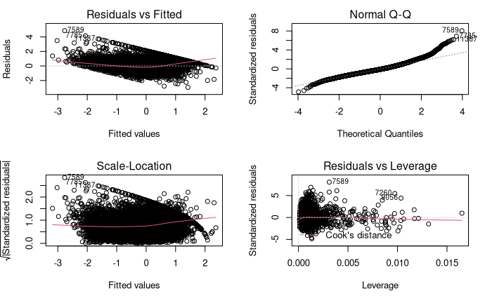

```r
par(mfrow = c(2, 2))
plot(mod00)
```

## Distribucion de los residuos

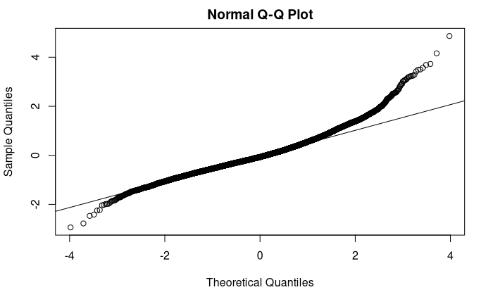

```r
qqnorm(mod00$residuals)
qqline(mod00$residuals)
```

```r
csv_test<-predict(object=mod00, newdata=test)
write.csv(x = csv_test, file = "csv_test.csv", row.names = TRUE)
```